# Decorative Data Point Icons

March 29, 2022

The following is intended to be an easy-to-follow tutorial on creating what I like to call decorative data points. In other words, this tutorial will show you how to take your favorite pictures and insert them into graphs as the data points! Have you ever been bored by the standard black or red dots that depict data points? Have you ever wanted some other image to appear instead of those plain shapes? For instance… Cats!? The following tutorial will show how to create both a photographic background for your graph and -more importantly- an attention-grabbing icon. This code for this tutorial is based on a blog post by Emma Rand: https://buzzrbeeline.blog/2018/06/13/fun-and-easy-r-graphs-with-images/

1. We’ll be using ggplot to create the final graph, so make sure that’s installed.

2. Install the following packages. As you can see, they mostly pertain to images.

```r
library(ggplot2)
library(png)
library(jpeg)
library(grid)
library(ggimage)
```

3. Let’s make up a small data set for demonstration purposes.

```r
cats <- data.frame(age = c(0.5, 1, 1.5, 2, 2.5, 3),
                  incidents = c(40, 34, 32, 22,18, 10))
```

3.1) Also, and very importantly, we are presuming that you have two photos in your working directory: one for a background, and one for the data point icon. For the purposes of this tutorial, we’ll call those “catbox.png” and “cat1.png”

4. The basic graph would look something like this.

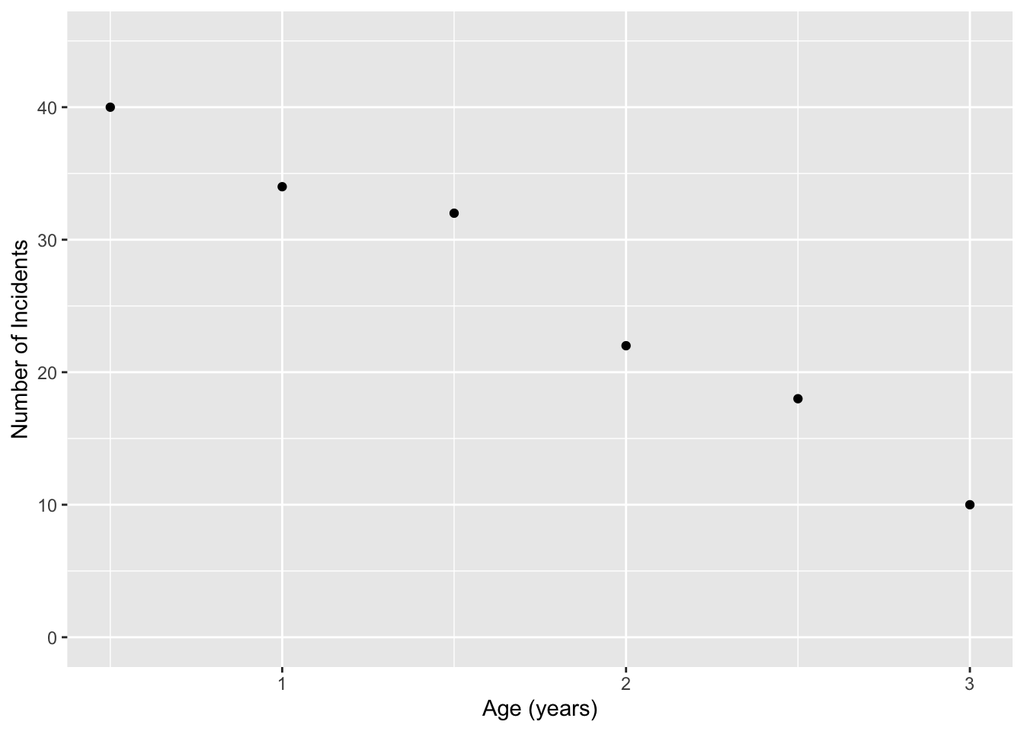

```r
ggplot(data = cats, aes(x = age, y = incidents)) +
  geom_point() +
  xlab("Age (years)") +
  ylab("Number of Incidents") +
  ylim(0, 45)
```

```r
img_catbox <- readPNG("/Library/Frameworks/R.framework/Versions/4.1/Resources/library/imager/extdata/catbox.png")
```

6. Let’s take a look at that graph now.

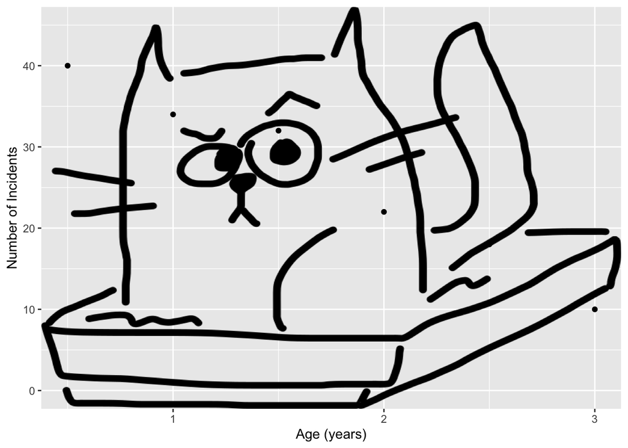

```r
ggplot(data = cats, aes(x = age, y = incidents)) +
  annotation_custom(rasterGrob(img_catbox,
                               width = unit(1,"npc"),
                               height = unit(1,"npc")),
                    -Inf, Inf, -Inf, Inf) +
  geom_point() +
  xlab("Age (years)") +
  ylab("Number of Incidents") +
  ylim(0, 45)
```

Frowney cat adds a twist to the graph.

7. Now let’s work on the decorative data point.

```r
cats$image1 <- "cat1.png"
```

That just added a column called “image1” to the dataframe “cats”.

8. Next, we modify the code for the graph to include our data point photo which is now labeled “image1”, for the column in our dataframe.

[figure not shown]

```r
ggplot(data = cats, aes(x = age, y = incidents)) +
  annotation_custom(rasterGrob(img_catbox,
                               width = unit(1,"npc"),
                               height = unit(1,"npc")),
                    -Inf, Inf, -Inf, Inf) +
  geom_image(aes(image = image1), size=.15) +
  xlab("Age (years)") +
  ylab("Number of Incidents") +
  ylim(0, 45)
```

9. Reel them in with the background, and keep them riveted with the data point icons!